# Breast Cancer Detection

Early detection of breast cancer is crucial for successful treatment. Conventional methods such as breast biopsy are more invasive and must be performed by a human specialist. However, samples obtained with less invasive techniques like fine needle aspiration method can be easily digitized and used for computer-aided diagnosis. To this end, the use of machine learning methods can significantly reduce the cost and time for the diagnostic process. This code snippet shows the reader how to train a Naive Bayes (NB) classifier for breast cancer detection.

**The dataset:** We utilise the dataset available at http://archive.ics.uci.edu/ml/datasets/breast+cancer+wisconsin+%28diagnostic%29

**Machine learning (ML) task:** We will train a NB model to detect the cancer given 30 features of the image. So, our ML task in this problem would be a classification. Let’s explore the dataset.

```r
myData <- read.csv("CancerData.csv", header=T)
dim(myData) # check dimensions of myData
```

```
[1] 569  32
```

```r
sapply(myData, class) # check the data types of each feature
```

```
                  id                label          radius.mean       perimeter.mean
           "integer"             "factor"            "numeric"            "numeric"
           area.mean      smoothness.mean     compactness.mean       concavity.mean
           "numeric"            "numeric"            "numeric"            "numeric"
        concave.mean        symmetry.mean         fractal.mean     perimeter.mean.1
           "numeric"            "numeric"            "numeric"            "numeric"
     radius.stderror   perimeter.stderror        area.stderror  smoothness.stderror
           "numeric"            "numeric"            "numeric"            "numeric"
compactness.stderror   concavity.stderror     concave.stderror    symmetry.stderror
           "numeric"            "numeric"            "numeric"            "numeric"
    fractal.stderror perimeter.stderror.1         radius.worst      perimeter.worst
           "numeric"            "numeric"            "numeric"            "numeric"
          area.worst     smoothness.worst    compactness.worst      concavity.worst
           "numeric"            "numeric"            "numeric"            "numeric"
       concave.worst       symmetry.worst        fractal.worst    perimeter.worst.1
           "numeric"            "numeric"            "numeric"            "numeric"
```

```r
levels(myData$label) # check different levels (values) for each class
```

```
[1] "B" "M"
```

```r
head(myData) # have a look at top data points in myData
```

|  | id | label | radius.mean | perimeter.mean | area.mean | smoothness.mean | compactness.mean | concavity.mean | concave.mean | symmetry.mean | fractal.mean | perimeter.mean.1 | radius.stderror | perimeter.stderror | area.stderror | smoothness.stderror | compactness.stderror | concavity.stderror | concave.stderror | symmetry.stderror | fractal.stderror | perimeter.stderror.1 | radius.worst | perimeter.worst | area.worst | smoothness.worst | compactness.worst | concavity.worst | concave.worst | … |
| --- | --- | --- | --- | --- | --- | --- | --- | --- | --- | --- | --- | --- | --- | --- | --- | --- | --- | --- | --- | --- | --- | --- | --- | --- | --- | --- | --- | --- | --- | --- |
| 1 | 842302 | M | 17.99 | 10.38 | 122.80 | 1001.0 | 0.11840 | 0.27760 | 0.3001 | 0.14710 | 0.2419 | 0.07871 | 1.0950 | 0.9053 | 8.589 | 153.40 | 0.006399 | 0.04904 | 0.05373 | 0.01587 | 0.03003 | 0.006193 | 25.38 | 17.33 | 184.60 | 2019.0 | 0.1622 | 0.6656 | 0.7119 | … |
| 2 | 842517 | M | 20.57 | 17.77 | 132.90 | 1326.0 | 0.08474 | 0.07864 | 0.0869 | 0.07017 | 0.1812 | 0.05667 | 0.5435 | 0.7339 | 3.398 | 74.08 | 0.005225 | 0.01308 | 0.01860 | 0.01340 | 0.01389 | 0.003532 | 24.99 | 23.41 | 158.80 | 1956.0 | 0.1238 | 0.1866 | 0.2416 | … |
| 3 | 84300903 | M | 19.69 | 21.25 | 130.00 | 1203.0 | 0.10960 | 0.15990 | 0.1974 | 0.12790 | 0.2069 | 0.05999 | 0.7456 | 0.7869 | 4.585 | 94.03 | 0.006150 | 0.04006 | 0.03832 | 0.02058 | 0.02250 | 0.004571 | 23.57 | 25.53 | 152.50 | 1709.0 | 0.1444 | 0.4245 | 0.4504 | … |
| 4 | 84348301 | M | 11.42 | 20.38 | 77.58 | 386.1 | 0.14250 | 0.28390 | 0.2414 | 0.10520 | 0.2597 | 0.09744 | 0.4956 | 1.1560 | 3.445 | 27.23 | 0.009110 | 0.07458 | 0.05661 | 0.01867 | 0.05963 | 0.009208 | 14.91 | 26.50 | 98.87 | 567.7 | 0.2098 | 0.8663 | 0.6869 | … |
| 5 | 84358402 | M | 20.29 | 14.34 | 135.10 | 1297.0 | 0.10030 | 0.13280 | 0.1980 | 0.10430 | 0.1809 | 0.05883 | 0.7572 | 0.7813 | 5.438 | 94.44 | 0.011490 | 0.02461 | 0.05688 | 0.01885 | 0.01756 | 0.005115 | 22.54 | 16.67 | 152.20 | 1575.0 | 0.1374 | 0.2050 | 0.4000 | … |
| 6 | 843786 | M | 12.45 | 15.70 | 82.57 | 477.1 | 0.12780 | 0.17000 | 0.1578 | 0.08089 | 0.2087 | 0.07613 | 0.3345 | 0.8902 | 2.217 | 27.19 | 0.007510 | 0.03345 | 0.03672 | 0.01137 | 0.02165 | 0.005082 | 15.47 | 23.75 | 103.40 | 741.6 | 0.1791 | 0.5249 | 0.5355 | … |

```r
summary(myData) # a summary of class distributions
```

```
       id            label    radius.mean     perimeter.mean    area.mean
 Min.   :     8670   B:357   Min.   : 6.981   Min.   : 9.71   Min.   : 43.79
 1st Qu.:   869218   M:212   1st Qu.:11.700   1st Qu.:16.17   1st Qu.: 75.17
 Median :   906024           Median :13.370   Median :18.84   Median : 86.24
 Mean   : 30371831           Mean   :14.127   Mean   :19.29   Mean   : 91.97
 3rd Qu.:  8813129           3rd Qu.:15.780   3rd Qu.:21.80   3rd Qu.:104.10
 Max.   :911320502           Max.   :28.110   Max.   :39.28   Max.   :188.50
 smoothness.mean  compactness.mean  concavity.mean     concave.mean     symmetry.mean
 Min.   : 143.5   Min.   :0.05263   Min.   :0.01938   Min.   :0.00000   Min.   :0.00000
 1st Qu.: 420.3   1st Qu.:0.08637   1st Qu.:0.06492   1st Qu.:0.02956   1st Qu.:0.02031
 Median : 551.1   Median :0.09587   Median :0.09263   Median :0.06154   Median :0.03350
 Mean   : 654.9   Mean   :0.09636   Mean   :0.10434   Mean   :0.08880   Mean   :0.04892
 3rd Qu.: 782.7   3rd Qu.:0.10530   3rd Qu.:0.13040   3rd Qu.:0.13070   3rd Qu.:0.07400
 Max.   :2501.0   Max.   :0.16340   Max.   :0.34540   Max.   :0.42680   Max.   :0.20120
  fractal.mean    perimeter.mean.1  radius.stderror  perimeter.stderror area.stderror
 Min.   :0.1060   Min.   :0.04996   Min.   :0.1115   Min.   :0.3602     Min.   : 0.757
 1st Qu.:0.1619   1st Qu.:0.05770   1st Qu.:0.2324   1st Qu.:0.8339     1st Qu.: 1.606
 Median :0.1792   Median :0.06154   Median :0.3242   Median :1.1080     Median : 2.287
 Mean   :0.1812   Mean   :0.06280   Mean   :0.4052   Mean   :1.2169     Mean   : 2.866
 3rd Qu.:0.1957   3rd Qu.:0.06612   3rd Qu.:0.4789   3rd Qu.:1.4740     3rd Qu.: 3.357
 Max.   :0.3040   Max.   :0.09744   Max.   :2.8730   Max.   :4.8850     Max.   :21.980
 smoothness.stderror compactness.stderror concavity.stderror concave.stderror
 Min.   :  6.802     Min.   :0.001713     Min.   :0.002252   Min.   :0.00000
 1st Qu.: 17.850     1st Qu.:0.005169     1st Qu.:0.013080   1st Qu.:0.01509
 Median : 24.530     Median :0.006380     Median :0.020450   Median :0.02589
 Mean   : 40.337     Mean   :0.007041     Mean   :0.025478   Mean   :0.03189
 3rd Qu.: 45.190     3rd Qu.:0.008146     3rd Qu.:0.032450   3rd Qu.:0.04205
 Max.   :542.200     Max.   :0.031130     Max.   :0.135400   Max.   :0.39600
 symmetry.stderror  fractal.stderror   perimeter.stderror.1  radius.worst
 Min.   :0.000000   Min.   :0.007882   Min.   :0.0008948    Min.   : 7.93
 1st Qu.:0.007638   1st Qu.:0.015160   1st Qu.:0.0022480    1st Qu.:13.01
 Median :0.010930   Median :0.018730   Median :0.0031870    Median :14.97
 Mean   :0.011796   Mean   :0.020542   Mean   :0.0037949    Mean   :16.27
 3rd Qu.:0.014710   3rd Qu.:0.023480   3rd Qu.:0.0045580    3rd Qu.:18.79
 Max.   :0.052790   Max.   :0.078950   Max.   :0.0298400    Max.   :36.04
 perimeter.worst   area.worst     smoothness.worst compactness.worst concavity.worst
 Min.   :12.02   Min.   : 50.41   Min.   : 185.2   Min.   :0.07117   Min.   :0.02729
 1st Qu.:21.08   1st Qu.: 84.11   1st Qu.: 515.3   1st Qu.:0.11660   1st Qu.:0.14720
 Median :25.41   Median : 97.66   Median : 686.5   Median :0.13130   Median :0.21190
 Mean   :25.68   Mean   :107.26   Mean   : 880.6   Mean   :0.13237   Mean   :0.25427
 3rd Qu.:29.72   3rd Qu.:125.40   3rd Qu.:1084.0   3rd Qu.:0.14600   3rd Qu.:0.33910
 Max.   :49.54   Max.   :251.20   Max.   :4254.0   Max.   :0.22260   Max.   :1.05800
 concave.worst    symmetry.worst    fractal.worst    perimeter.worst.1
 Min.   :0.0000   Min.   :0.00000   Min.   :0.1565   Min.   :0.05504
 1st Qu.:0.1145   1st Qu.:0.06493   1st Qu.:0.2504   1st Qu.:0.07146
 Median :0.2267   Median :0.09993   Median :0.2822   Median :0.08004
 Mean   :0.2722   Mean   :0.11461   Mean   :0.2901   Mean   :0.08395
 3rd Qu.:0.3829   3rd Qu.:0.16140   3rd Qu.:0.3179   3rd Qu.:0.09208
 Max.   :1.2520   Max.   :0.29100   Max.   :0.6638   Max.   :0.20750
```

```r
prop.table(table(myData$label)) # Ratio between two classes
```

```
        B         M
0.6274165 0.3725835
```

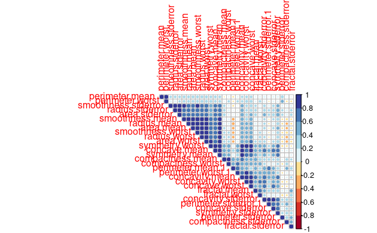

```r
library(corrplot) # Load libraries to plot correlation
library(RColorBrewer)
M <-cor(myData[,3:ncol(myData)])
corrplot(M, type="upper", order="hclust", col=brewer.pal(n=10, name="RdYlBu"))
```

We notice that the data is slightly imbalanced and there are highly correlated features. However, we do not remove correlated features from the dataset, nor do we deal with the class imbalanced problem of this analysis as the purpose of this post to demonstrate you how to train NB model for the dataset. Therefore we will use our dataset as it’s in model building.

**Creating training and validation datasets:** We’re going to construct a 80/20 partitioning for the training and validation sets. We use the createDataPartition function from the caret package for this purpose.

```r
set.seed(12)
#install.packages("caret") #If the caret package is not installed on your system, uncomment this line to install it first
library(caret) #Loading the library
tr_index <- createDataPartition(myData$label, p=0.80, list=FALSE) # List of 80% of the rows
trainSet <- myData[tr_index,] # select 80% of the data for the trainSet
testSet <- myData[-tr_index,] # Select the remaining 20% of data for testSet
```

```r
#install.packages("e1071") #If the e1071 package is not installed on your system, uncomment this line to install it first
library(e1071)
NBclassfier=naiveBayes(label~., data=trainSet[,2:ncol(trainSet)]) # Once you call this line, R fits the NB model using trainSet
print(NBclassfier) # Check the newly fitted model to see if everything is OK.
```

```
Naive Bayes Classifier for Discrete Predictors

Call:
naiveBayes.default(x = X, y = Y, laplace = laplace)

A-priori probabilities:
Y
       B        M
0.627193 0.372807

Conditional probabilities:
   radius.mean
Y       [,1]     [,2]
  B 12.28738 1.730600
  M 17.51965 3.101673

   perimeter.mean
Y       [,1]    [,2]
  B 17.69794 4.01135
  M 21.70582 3.67748

   area.mean
Y        [,1]     [,2]
  B  79.04063 11.47299
  M 115.71647 21.11783

   smoothness.mean
Y       [,1]     [,2]
  B 472.8682 131.9559
  M 981.2335 350.8699

   compactness.mean
Y         [,1]       [,2]
  B 0.09269678 0.01338821
  M 0.10214365 0.01246641

   concavity.mean
Y         [,1]       [,2]
  B 0.08142664 0.03404852
  M 0.14466382 0.05492977
```

[output cut: 105 more lines]

```

   symmetry.worst
Y         [,1]       [,2]
  B 0.07582791 0.03488616
  M 0.18157918 0.04636119

   fractal.worst
Y        [,1]       [,2]
  B 0.2692129 0.04188110
  M 0.3242171 0.07665267

   perimeter.worst.1
Y         [,1]       [,2]
  B 0.07930696 0.01386718
  M 0.09153382 0.02181732
```

**Make predictions:** Now let’s apply the above model to assign labels for test cases in testSet. Then we create the confusion matrix, a table that is often used to describe the performance of a classifier.

```r
  testPrediction=predict(NBclassfier, newdata=testSet[,2:ncol(testSet)], type="class") # Assign labels for each test case
  confusionMatrix(testPrediction, testSet$label) # Print confusion matrix
```

```
Confusion Matrix and Statistics

          Reference
Prediction  B  M
         B 68  4
         M  3 38

               Accuracy : 0.9381
                 95% CI : (0.8765, 0.9747)
    No Information Rate : 0.6283
    P-Value [Acc > NIR] : 1.718e-14

                  Kappa : 0.8667

 Mcnemar's Test P-Value : 1

            Sensitivity : 0.9577
            Specificity : 0.9048
         Pos Pred Value : 0.9444
         Neg Pred Value : 0.9268
             Prevalence : 0.6283
         Detection Rate : 0.6018
   Detection Prevalence : 0.6372
      Balanced Accuracy : 0.9313

       'Positive' Class : B
```

We can see that the accuracy is 93.81%. It was a small test set, but whether or not that accuracy is sufficient depends on the problem context and is based on many other factors.